[figure not shown]

```python
display(Image('yelp.png'))
```

**Group Topic:** Yelp Las Vegas Restaurants Analysis  
**Group Member:** Palash Pandya, Shruti Sharma, Rui Ma

# 1. Introduction

When it comes to online ratings and reviews, everyone benefits. They have the ability to enhance merchant credibility, improve comparison shopping rankings, and raise conversion rates. Reviews can increase customer engagement and also monitor customer service efforts. Ratings and reviews can achieve all of these and more through the power of word of mouth marketing. Yelp is one of the leading websites that has been dedicated to merchants ratings and reviews including restaurants, hair salons and makeup artists, for a long time.

### Questions of Interest

- **Q1:** What is the most popular type of restaurant in Las Vegas? What is the trend of check-in time for this kind of restaurant?  
  Figure out the most popular type of restaurant and check-ins trends over a duration of the time.
- **Q2:** What do we know about users?  
  Analyze users' yelping duration, average star of their reviews, types of restaurants they visit, the businesses they checked-in and the frequency they checked in.
- **Q3:** Where are the best restaurants in Las Vegas?  
  Figure out where can we find the best restaurants with rating above 3, where can we find best cuisines i.e. NightLife, Japanese food, in Las Vegas?
- **Q4:** What did people say about Las Vegas restaurants?  
  Analyze reviews using sentiment analysis.

### Description of Data

In order to work together more efficiently and to easily verify our output using tableau and other tools, we convert original one json file to four seperated csv file. They are 'business.csv', 'checkin.csv', 'user.csv'and 'review.csv'.

#### Attributes of 'business.csv' are as follows:

- business_id: ID of the business
- name: name of the business
- city: city of the business
- latitude: latitude of the business
- longitude: longitude of the business
- stars: average rating of the business
- review_count: number of reviews received
- categories: multiple categories of the business

#### Attributes of 'checkin.csv' are as follows:

- business_id: ID of the business
- Date: The dates when checkin's were done for that place

#### Attributes of 'user.csv' are as follows:

- user_id: ID of the user
- name: Name of the user
- review_count: Number of reviews given by user
- yelping_since: The dates since user started yelping
- useful: Count of people who found the user's review useful
- funny: Count of people who found the user's review funny
- cool: Count of people who found the user's review cool
- fans: Count of people who found the user's review fans
- elite: The elite member badge given by Yelp to the user's if they reach a certain level
- average_stars : Average Star given by a user throughout their yelp usage

#### Attribues of 'review.csv' are as follows:

- review_id: ID of the review
- user_id: ID of the user
- business_id: ID of the business
- stars: ratings of the business
- date: review date
- text: review from the user
- useful: number of users who vote a review as usefull
- funny: number of users who vote a review as funny
- cool: number of users who vote a review as cool

### Summary of Main Tasks

#### Data Input and Filter

- Convert one 8.65GB json file to five json files.
- Filter out 'Las Vegas', 'Restaurants' data and columns needed, write into seperate CSV files.

#### Data Cleaning

Data cleaning is covered through the whole report, we use:

- Missing data: Replace all the NaN values by 0 to count the elite members of the Yelp.
- Remove space at the beginning and end of check-in time.
- Indexing and reindexing.
- Renaming axis indexes.
- Binning: Create bins for restaurant scores, counts, etc.
- Computing dummy variables for restaurant type.
- Discretization: Convert multi-valued cell into seperated cell, i.e. seperate the time stamp data into Date, Month and Year Columns.
- Manipulate time stamp to corresponding weekday.

#### Data Manipulation

- Slicing: slice top 50 types of the category for Businesses analysis categorically.
- Arithmetic operations: find all business locations in each year using (business built year <= target year), convert absolute value to relative value for scores of restaurant types.
- Sorting and ranking: find the Top 10 Las Vegas restaurants in each year.
- Groupby: using groupby function to group data for individual year, user or business.
- Group operations: calculate average, count and other statistic attributes for groups.
- Merge: Merge two dataframes,like business and review, to cross-analyze.
- Reshaping: Using melt to transform checkin time for each business from wide to long.

#### Natural Language Processing

- Converting to lower case.
- Tokenization.
- Removing stop words.
- Stemming/Lemmatization.

#### Visualization

- **Interactive bar plot visualization:** Visualize the top 10 restaurants and Categories of Cusines for Las Vegas.
- **Interactive stacked bar plot:** Visualize the percentage of score from 1-5 for each top type of restaurants.
- **Interactive line plot visualization:** Visualize the most popular checkin time in Las Vegas and time distribution of top Las Vegas restaurant types.
- **Interactive subplot visualization:** Using bar plot, pie plot, visualize the users based on Review counts per user , average stars per user , Elite Vs. Non-Elite users and Number of Users for the year 2005 to 2018 using the application Yelp.
- **Interactive map visualization:** Using mapbox, slider and button to show the increasing of restaurants in Las Vegas from 2011 - 2018. Besides, creating heatmap to show score distribution of Las Vegas restaurants/
- **Word cloud Visualization:** using word cloud to show the most common words in Mexican reviews.

# 2. Data Acquisition and Cleaning

## Preparation

```python
%pylab inline
from IPython.display import display
from IPython.display import Image
import json
import csv
import matplotlib.pyplot as plt
import seaborn as sns
import plotly.graph_objects as go
import plotly.express as px
import pandas as pd
import numpy as np
from datetime import datetime
import nltk
from nltk.tokenize import sent_tokenize, word_tokenize
from nltk.probability import FreqDist
from nltk.corpus import stopwords
from collections import Counter
from nltk.stem import PorterStemmer,WordNetLemmatizer
from wordcloud import WordCloud;
```

## Data Input and Filtering

**Step 2.1** Download JSON file from 'yelp.com/dataset'  
There are 5 JSONs in one file, total 8.65GB, including 6,685,900 reviews, 192,609 businesses, 1,223,094 tips by 1,637,138 users.

**Step 2.2** Seperate one JSON file to 5 JSON files: business, checkin, review, tip, user.

```python
originalFile = open('yelp_dataset','r')
print('Open original file: yelp_dataset.')
currentFile = None
index = 0
while True:
    line = originalFile.readline().strip()
    if line == None:
        if currentFile != None:
            currentFile.close()
        break
    if not line.startswith('{'):
        if currentFile != None:
            currentFile.close()
        fileName = line[0:line.find('.')]
        fileName = fileName.replace('\x00','')
        if fileName == 'photo':
            break
        print('Creating',fileName, 'started from line', str(index))
        currentFile = open(fileName,'wb')
        line = line[line.find('{'):]
    currentFile.write(line.encode())
    currentFile.write('\n'.encode())
    index += 1
print('You got all the files.')
```

```
Open original file: yelp_dataset.
Creating business started from line 0
Creating checkin started from line 192609
Creating review started from line 354559
Creating tip started from line 7040459
Creating user started from line 8263553
You got all the files.
```

**Step 2.3** Convert JSON files to csv files, filter Las Vegas restaurant data.

```python
# encoding: utf-8

# Define the city we plan to research.
CITY = 'Las Vegas'
BUSINESS_SET = set()
USER_SET = set()

# Define headers for 5 csv files.
BUSINESS_TABLE_COLUMNS = ["business_id", "name", "city", "latitude", "longitude", "stars", "review_count", "categories"]
REVIEW_TABLE_COLUMNS = ["review_id", "user_id", "business_id", "stars", "date", "text", "useful", "funny", "cool"]
USER_TABLE_COLUMNS = ["user_id", "name", "review_count", "yelping_since", "useful", "funny", "cool", "fans", "elite", "average_stars"]
CHECKIN_TABLE_COLUMNS = ["business_id", "date"]
TIP_TABLE_COLUMNS = ["text", "date", "compliment_count", "business_id", "user_id"]

def create_csv(tableName, table_row_names):
    print('Creating', tableName, 'csv file.')
    preload_necessary_data(tableName)
    rawJsonFile = open(tableName, 'r')
    outputFile = open(tableName + '.csv', 'w')
    writer = csv.writer(outputFile)
    writer.writerow(table_row_names)
    index = 0
    while True:
        line = rawJsonFile.readline().strip()
        if line == None or len(line) == 0:
            break
        current_dict = json.loads(line)
        if csv_write_row(tableName, current_dict, table_row_names, writer):
            index += 1
            if (index % 100000 == 0):
                print ("Handling ", index)
    print(str(index), 'rows in', tableName, 'file.')
    outputFile.close()
    rawJsonFile.close()

# Defind a helper function to write rows in csv file.
def csv_write_row(tableName, current_dict, table_row_names, writer):
    canWrite = False
    if tableName == 'business' and current_dict['city'] == CITY:
        categories = current_dict['categories']
        if categories != None and ('food' in categories or 'restaurant' in categories or 'Food' in categories or "Restaurants" in categories):
            canWrite = True
    elif tableName == 'review':
        if current_dict['business_id'] in BUSINESS_SET:
            canWrite = True
    elif tableName == 'user' and current_dict['user_id'] in USER_SET:
        canWrite = True
    elif tableName == 'checkin' and current_dict['business_id'] in BUSINESS_SET:
        canWrite = True
    elif tableName == 'tip' and current_dict['business_id'] in BUSINESS_SET:
        canWrite = True
    if canWrite:
        currentRowInList = list()
        for item in table_row_names:
            tempValue = current_dict[item]
            currentRowInList.append(tempValue)
        writer.writerow(currentRowInList)
    return canWrite

# Check whether to load businessid and userid set.
def preload_necessary_data(tableName):
    business_required = ["review", "checkin", "tip"]
    user_required = ["user"]
    if tableName in business_required and len(BUSINESS_SET) == 0:
        loading_business()
    elif tableName in user_required and len(USER_SET) == 0:
        loading_user()

# Add businessid, userid to corresponding set.
def loading_business():
    fileHandler = open ("business.csv", "r")
    csv_f = csv.reader(fileHandler)
    for row in csv_f:
        business_id = row[0]
        BUSINESS_SET.add(business_id)
    return BUSINESS_SET

def loading_user():
    fileHandler = open ("review.csv", "r")
    csv_f = csv.reader(fileHandler)
    for row in csv_f:
        USER_SET.add(row[1])
    return USER_SET
```

```python
# Create Las Vegas business csv file.
create_csv('business', BUSINESS_TABLE_COLUMNS)
```

```
Creating business csv file.
8286 rows in business file.
```

```python
# Create Las Vegas business reviews csv file.
create_csv('review', REVIEW_TABLE_COLUMNS)
```

```
Creating review csv file.
Handling  100000
Handling  200000
Handling  300000
Handling  400000
Handling  500000
Handling  600000
Handling  700000
Handling  800000
Handling  900000
Handling  1000000
Handling  1100000
Handling  1200000
Handling  1300000
1334902 rows in review file.
```

```python
# Create Las Vegas business users csv file.
create_csv('user', USER_TABLE_COLUMNS)
```

```
Creating user csv file.
Handling  100000
Handling  200000
Handling  300000
Handling  400000
452420 rows in user file.
```

```python
# Create Las Vegas business checkins csv file.
create_csv('checkin', CHECKIN_TABLE_COLUMNS)
```

```
Creating checkin csv file.
8062 rows in checkin file.
```

# 3.Data Analysis and Visualization

## 3.1 Explore Individual Dataset and Preliminary Analysis

- 8286 records of business
- 8062 records of checkin
- 452420 records of users
- 1334902 records or reviews

```python
# Read csv files.
business = pd.read_csv('business.csv')
checkin = pd.read_csv('checkin.csv')
user = pd.read_csv('user.csv')
review = pd.read_csv('review.csv')
```

```python
# Show business data.
business.head()
```

|  | business_id | name | city | latitude | longitude | stars | review_count | categories |
| --- | --- | --- | --- | --- | --- | --- | --- | --- |
| 0 | PZ-LZzSlhSe9utkQYU8pFg | Carluccio's Tivoli Gardens | Las Vegas | 36.100016 | -115.128528 | 4.0 | 40 | Restaurants, Italian |
| 1 | tstimHoMcYbkSC4eBA1wEg | Maria's Mexican Restaurant & Bakery | Las Vegas | 36.195615 | -115.040529 | 4.5 | 184 | Mexican, Restaurants, Patisserie/Cake Shop, Fo... |
| 2 | NBn4hgfGtNz91k3VsDZlmw | Three Square | Las Vegas | 36.236053 | -115.096454 | 5.0 | 44 | Local Services, Food Banks, Community Service/... |
| 3 | kANF0dbeoW34s2vwh6Umfw | Dairy Queen | Las Vegas | 36.125031 | -115.225620 | 2.0 | 33 | Fast Food, Food, Restaurants, Ice Cream & Froz... |
| 4 | YK5eFV8uS1bCmp8GeiQ-Qg | All Star Donuts & Kolaches | Las Vegas | 36.115813 | -115.095457 | 4.0 | 6 | Food, Donuts |

```python
# Show checkin data.
checkin.head()
```

|  | business_id | date |
| --- | --- | --- |
| 0 | --9e1ONYQuAa-CB_Rrw7Tw | 2010-02-08 05:56:47, 2010-02-15 04:47:42, 2010... |
| 1 | --q7kSBRb0vWC8lSkXFByA | 2010-09-26 23:08:32, 2010-10-03 09:06:15, 2010... |
| 2 | -0BxAGlIk5DJAGVkpqBXxg | 2010-08-20 19:44:47, 2010-08-26 23:54:03, 2010... |
| 3 | -0RkJ_uIduNLWQrphbADRw | 2018-08-30 16:32:18, 2018-09-01 19:39:03, 2018... |
| 4 | -1m9o3vGRA8IBPNvNqKLmA | 2017-10-25 00:48:29, 2017-10-26 02:31:11, 2017... |

```python
# Show user data.
user.head()
```

|  | user_id | name | review_count | yelping_since | useful | funny | cool | fans | elite | average_stars |
| --- | --- | --- | --- | --- | --- | --- | --- | --- | --- | --- |
| 0 | bc8C_eETBWL0olvFSJJd0w | David | 16 | 2013-10-04 00:16:10 | 28 | 8 | 10 | 0 | NaN | 3.71 |
| 1 | dD0gZpBctWGdWo9WlGuhlA | Angela | 17 | 2014-05-22 15:57:30 | 30 | 4 | 14 | 5 | NaN | 4.85 |
| 2 | TEtzbpgA2BFBrC0y0sCbfw | Keane | 1122 | 2006-02-15 18:29:35 | 13311 | 19356 | 15319 | 696 | 2006,2007,2008,2009,2010,2011,2012,2013 | 4.39 |
| 3 | KGuqerdeNhxzXZEyBaqqSw | Andre | 6 | 2014-06-07 01:50:09 | 1 | 0 | 1 | 0 | NaN | 4.33 |
| 4 | T0gWkTHWRChVUe_Dn1F8nw | Tanya | 859 | 2005-07-20 22:38:17 | 1630 | 693 | 1244 | 57 | 2006,2007,2008,2009,2010,2011,2012 | 4.21 |

```python
# Show review data.
review.head()
```

|  | review_id | user_id | business_id | stars | date | text | useful | funny | cool |
| --- | --- | --- | --- | --- | --- | --- | --- | --- | --- |
| 0 | kbtscdyz6lvrtGjD1quQTg | FIk4lQQu1eTe2EpzQ4xhBA | 8mIrX_LrOnAqWsB5JrOojQ | 4.0 | 2011-11-30 02:11:15 | Like walking back in time, every Saturday morn... | 0 | 0 | 0 |
| 1 | IByf6mVY0WA838XNSh-5MA | 3CJUJILq7CLHk_9OrvpvQg | I4Nr-MVc26qWr08-S3Q1ow | 4.0 | 2016-01-17 05:26:22 | The food is always good and the prices are rea... | 0 | 0 | 0 |
| 2 | S337tATeouQJdoPYyir29w | 2mxBNBeFrgDszqGS5tdEHA | d_L-rfS1vT3JMzgCUGtiow | 5.0 | 2016-07-25 03:57:19 | Pick any meat on the planet and the chef will ... | 0 | 0 | 0 |
| 3 | D_UvaenM25iNd6aehTZ0MA | 8NwU4TRsD3S6gIfBqFzDMQ | Sfc8Haz2Yri8Mo1L0E0TsA | 5.0 | 2012-11-06 03:41:43 | Great food, great service. Obviously fried chi... | 0 | 0 | 0 |
| 4 | qm97yMwREr7BKkexlwLFbg | TTRVdTXKcq-xn6-1IWbwEw | Gyrez6K8f1AyR7dzW9fvAw | 5.0 | 2013-12-28 22:28:08 | their pettuccine was fresh-made in the morning... | 0 | 0 | 1 |

### 3.1.1 What is the most popular type of restaurants in Las Vegas?

```python
# Count the number of each single type. One business can have more than one type.
business_types = business.categories.str.split(',', expand=True)
business = pd.concat((business, business_types), axis=1)
types = business.iloc[:,8:].stack().str.strip().value_counts()
types = pd.DataFrame(types).reset_index()
types.columns = ['Type', 'Count']
```

```python
# Look through top 50 types
print(list(types[:50]['Type']))
```

```
['Restaurants', 'Food', 'Nightlife', 'Fast Food', 'Bars', 'American (Traditional)', 'Mexican', 'Coffee & Tea', 'Sandwiches', 'Pizza', 'American (New)', 'Burgers', 'Breakfast & Brunch', 'Specialty Food', 'Desserts', 'Chinese', 'Italian', 'Shopping', 'Event Planning & Services', 'Seafood', 'Japanese',…
```

**Top 10 type by category:**  
Nightlife, Fast Food, Bars, Coffee & Tea, Sandwiches, Pizza, Burgers, Breakfast & Brunch, Specialty Food, Desserts

**Top 10 type by region:**  
American (Traditional), Mexican, American (New), Chinese, Italian, Japanese, Thai, Mediterranean, Hawaiian, Korean

```python
types.set_index('Type',inplace=True)
```

```python
# Filter out business count of top 10 types.
TOP10Cat = types[types.index.isin(['Nightlife', 'Fast Food', 'Bars', 'Coffee & Tea', 'Sandwiches', 'Pizza', 'Burgers', 'Breakfast & Brunch', 'Specialty Food', 'Desserts'])]
TOP10Reg = types[types.index.isin(['American (Traditional)', 'Mexican', 'American (New)', 'Chinese', 'Italian', 'Japanese', 'Thai', 'Mediterranean', 'Hawaiian', 'Korean'])]
```

```python
TOP10Cat.reset_index(inplace=True)
TOP10Reg.reset_index(inplace=True)
```

```python
# Using subplot to show top 10 types of restaurants by cuisine and by category.
from plotly.subplots import make_subplots
fig = make_subplots(
    rows=1, cols=2, subplot_titles=("Top 10 Cuisine", "Top 10 Category"), shared_yaxes=True, horizontal_spacing=0.02)

fig.add_trace(go.Bar(x=TOP10Reg['Type'], y=TOP10Reg['Count'], name='Cuisine'), row=1, col=1)
fig.add_trace(go.Bar(x=TOP10Cat['Type'], y=TOP10Cat['Count'], name='Category'), row=1, col=2)

fig.update_layout(title='Top Las Vegas Restaurant Types', yaxis_title='count')

fig.show()
```

[figure not shown]

```python
display(Image('1.png'))
```

### 3.1.2 What is the most popular checkin time in Las Vegas?

```python
# Convert multi-value checkin time to seperate values, expand the column.
allCheckinTime = checkin['date'].str.split(',',expand=True).stack().str.strip()
```

```python
# Define a function to convert time stamp in a given check-in time dataframe
# to date, time, year, month, day, weekday.

def get_checkinTime_df(checkinTime):
    checkinTime = pd.DataFrame(checkinTime)
    checkinTime = checkinTime[0].str.split(' ', expand=True)
    checkinTime = checkinTime.reset_index().drop(['level_0','level_1'],axis=1)
    checkinTime.columns = ['Date', 'Time']
    date = checkinTime['Date'].str.split('-', expand=True)
    checkinTime['Date'] = pd.to_datetime(checkinTime['Date'])
    checkinTime = pd.concat((checkinTime, date), axis=1)
    checkinTime.columns = ['Date','Time','Year','Month','Day']
    checkinTime['weekDay'] = checkinTime['Date'].dt.day_name()
    return checkinTime
```

```python
# Convert all businesses' checkin time dataframe 'allCheckinTime' to target format
allCheckinTime = get_checkinTime_df(allCheckinTime)
```

```python
allCheckinTime.head()
```

|  | Date | Time | Year | Month | Day | weekDay |
| --- | --- | --- | --- | --- | --- | --- |
| 0 | 2010-02-08 | 05:56:47 | 2010 | 02 | 08 | Monday |
| 1 | 2010-02-15 | 04:47:42 | 2010 | 02 | 15 | Monday |
| 2 | 2010-02-22 | 03:20:16 | 2010 | 02 | 22 | Monday |
| 3 | 2010-03-12 | 05:18:41 | 2010 | 03 | 12 | Friday |
| 4 | 2010-03-19 | 03:42:08 | 2010 | 03 | 19 | Friday |

```python
# Get the 'hour' value in each time, save it to a new column in 'allCheckinTime'.
allCheckinTime['hour'] = allCheckinTime['Time'].str.slice(stop=2)
```

```python
# Groupby 'hour' to show hourly count of check-in, save it to a new dataframe 'allCheckinTimeHourCopy'
# Reset column names.
allCheckinTimeHour = allCheckinTime.groupby('hour')['Date'].count()
allCheckinTimeHourCopy = allCheckinTimeHour.reset_index()
allCheckinTimeHourCopy.columns = ['hour', 'check-in count']
```

```python
# Plot hourly check-in time dirstribution.
fig = go.Figure()
fig.add_trace(go.Scatter(x=list(range(0,24)), y=allCheckinTimeHourCopy['check-in count'], name='check-in count',
                         line=dict(color='firebrick', width=2)))
fig.update_layout(title='Check-in Time Distribution of Las Vegas Restaurants',
                   xaxis_title='Hour',
                   yaxis_title='check-in count')
fig.show()
```

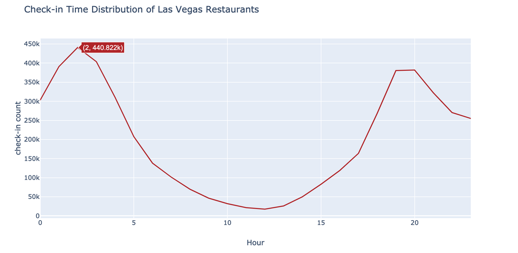

```python
display(Image('2.png'))
```

**Analysis:** Las Vegas is indeed a 'night city'. most people check in from 7pm to 4am. **2 am** is the most popular check-in time in Las Vegas. Is this because we have so many 'NightLife' and 'Bar' restaurants? We will look deep into that.

### 3.1.3 What we know about users?

```python
# Data cleaning
user['elite'] = user['elite'].fillna(0)
user.head()
```

|  | user_id | name | review_count | yelping_since | useful | funny | cool | fans | elite | average_stars |
| --- | --- | --- | --- | --- | --- | --- | --- | --- | --- | --- |
| 0 | bc8C_eETBWL0olvFSJJd0w | David | 16 | 2013-10-04 00:16:10 | 28 | 8 | 10 | 0 | 0 | 3.71 |
| 1 | dD0gZpBctWGdWo9WlGuhlA | Angela | 17 | 2014-05-22 15:57:30 | 30 | 4 | 14 | 5 | 0 | 4.85 |
| 2 | TEtzbpgA2BFBrC0y0sCbfw | Keane | 1122 | 2006-02-15 18:29:35 | 13311 | 19356 | 15319 | 696 | 2006,2007,2008,2009,2010,2011,2012,2013 | 4.39 |
| 3 | KGuqerdeNhxzXZEyBaqqSw | Andre | 6 | 2014-06-07 01:50:09 | 1 | 0 | 1 | 0 | 0 | 4.33 |
| 4 | T0gWkTHWRChVUe_Dn1F8nw | Tanya | 859 | 2005-07-20 22:38:17 | 1630 | 693 | 1244 | 57 | 2006,2007,2008,2009,2010,2011,2012 | 4.21 |

```python
# Create dummy variable 'Elite'
user.loc[:,'Elite'] = 1
user.loc[user['elite'] == 0 , 'Elite'] = 0
user.head()
```

|  | user_id | name | review_count | yelping_since | useful | funny | cool | fans | elite | average_stars | Elite |
| --- | --- | --- | --- | --- | --- | --- | --- | --- | --- | --- | --- |
| 0 | bc8C_eETBWL0olvFSJJd0w | David | 16 | 2013-10-04 00:16:10 | 28 | 8 | 10 | 0 | 0 | 3.71 | 0 |
| 1 | dD0gZpBctWGdWo9WlGuhlA | Angela | 17 | 2014-05-22 15:57:30 | 30 | 4 | 14 | 5 | 0 | 4.85 | 0 |
| 2 | TEtzbpgA2BFBrC0y0sCbfw | Keane | 1122 | 2006-02-15 18:29:35 | 13311 | 19356 | 15319 | 696 | 2006,2007,2008,2009,2010,2011,2012,2013 | 4.39 | 1 |
| 3 | KGuqerdeNhxzXZEyBaqqSw | Andre | 6 | 2014-06-07 01:50:09 | 1 | 0 | 1 | 0 | 0 | 4.33 | 0 |
| 4 | T0gWkTHWRChVUe_Dn1F8nw | Tanya | 859 | 2005-07-20 22:38:17 | 1630 | 693 | 1244 | 57 | 2006,2007,2008,2009,2010,2011,2012 | 4.21 | 1 |

```python
# Create bins for review_count
bins = np.linspace(start=0, stop=50, num=11)
user['Review Count Bin'] = pd.cut(user['review_count'], bins)
user.head()
```

|  | user_id | name | review_count | yelping_since | useful | funny | cool | fans | elite | average_stars | Elite | Review Count Bin |
| --- | --- | --- | --- | --- | --- | --- | --- | --- | --- | --- | --- | --- |
| 0 | bc8C_eETBWL0olvFSJJd0w | David | 16 | 2013-10-04 00:16:10 | 28 | 8 | 10 | 0 | 0 | 3.71 | 0 | (15.0, 20.0] |
| 1 | dD0gZpBctWGdWo9WlGuhlA | Angela | 17 | 2014-05-22 15:57:30 | 30 | 4 | 14 | 5 | 0 | 4.85 | 0 | (15.0, 20.0] |
| 2 | TEtzbpgA2BFBrC0y0sCbfw | Keane | 1122 | 2006-02-15 18:29:35 | 13311 | 19356 | 15319 | 696 | 2006,2007,2008,2009,2010,2011,2012,2013 | 4.39 | 1 | NaN |
| 3 | KGuqerdeNhxzXZEyBaqqSw | Andre | 6 | 2014-06-07 01:50:09 | 1 | 0 | 1 | 0 | 0 | 4.33 | 0 | (5.0, 10.0] |
| 4 | T0gWkTHWRChVUe_Dn1F8nw | Tanya | 859 | 2005-07-20 22:38:17 | 1630 | 693 | 1244 | 57 | 2006,2007,2008,2009,2010,2011,2012 | 4.21 | 1 | NaN |

```python
# Getting the sum to know the count of elite members
user['Elite'].sum()
```

```
38802
```

```python
# To know the count of users
user['Elite'].count()
```

```
452420
```

```python
reviewCountBin = pd.DataFrame(user['Review Count Bin'].value_counts())
reviewCountBin.reset_index(inplace=True)
```

```python
# getting the review count
reviewCountBin[7:].sum()
```

```
Review Count Bin    26198
dtype: int64
```

```python
# Creating bins to get to know about reviews per user
reviewCountBin = reviewCountBin[:7].append({'index':'others','Review Count Bin': 26198},ignore_index=True)
reviewCountBin.columns = ['reviewBin', 'Count']
reviewCountBin
```

|  | reviewBin | Count |
| --- | --- | --- |
| 0 | (0.0, 5.0] | 149922 |
| 1 | (5.0, 10.0] | 71130 |
| 2 | (10.0, 15.0] | 42972 |
| 3 | (15.0, 20.0] | 29358 |
| 4 | (20.0, 25.0] | 21357 |
| 5 | (25.0, 30.0] | 16367 |
| 6 | (30.0, 35.0] | 12881 |
| 7 | others | 26198 |

```python
# Seperating Date, time year and month for further analysis
user['time'] = pd.to_datetime(user['yelping_since'])
user['dates'] = user['time'].dt.date
user['Year'] = pd.DatetimeIndex(user['dates']).year
user['Month'] = pd.DatetimeIndex(user['dates']).month
user.head()
```

|  | user_id | name | review_count | yelping_since | useful | funny | cool | fans | elite | average_stars | Elite | Review Count Bin | time | dates | Year | Month |
| --- | --- | --- | --- | --- | --- | --- | --- | --- | --- | --- | --- | --- | --- | --- | --- | --- |
| 0 | bc8C_eETBWL0olvFSJJd0w | David | 16 | 2013-10-04 00:16:10 | 28 | 8 | 10 | 0 | 0 | 3.71 | 0 | (15.0, 20.0] | 2013-10-04 00:16:10 | 2013-10-04 | 2013 | 10 |
| 1 | dD0gZpBctWGdWo9WlGuhlA | Angela | 17 | 2014-05-22 15:57:30 | 30 | 4 | 14 | 5 | 0 | 4.85 | 0 | (15.0, 20.0] | 2014-05-22 15:57:30 | 2014-05-22 | 2014 | 5 |
| 2 | TEtzbpgA2BFBrC0y0sCbfw | Keane | 1122 | 2006-02-15 18:29:35 | 13311 | 19356 | 15319 | 696 | 2006,2007,2008,2009,2010,2011,2012,2013 | 4.39 | 1 | NaN | 2006-02-15 18:29:35 | 2006-02-15 | 2006 | 2 |
| 3 | KGuqerdeNhxzXZEyBaqqSw | Andre | 6 | 2014-06-07 01:50:09 | 1 | 0 | 1 | 0 | 0 | 4.33 | 0 | (5.0, 10.0] | 2014-06-07 01:50:09 | 2014-06-07 | 2014 | 6 |
| 4 | T0gWkTHWRChVUe_Dn1F8nw | Tanya | 859 | 2005-07-20 22:38:17 | 1630 | 693 | 1244 | 57 | 2006,2007,2008,2009,2010,2011,2012 | 4.21 | 1 | NaN | 2005-07-20 22:38:17 | 2005-07-20 | 2005 | 7 |

```python
# Grouping them by year to get to know more about the users each year
year_group = user.groupby(by='Year')
```

```python
# Creating List for groups
Lt1 = []
for name, group in year_group:
    lt = []
    lt.append(name)
    lt.append(len(group))
    Lt1.append(lt)
```

```python
# Converting List to Dataframe
Time = pd.DataFrame(Lt1)
Time = Time.rename(columns = { 0 : 'Year', 1: 'Users'})
Time
```

|  | Year | Users |
| --- | --- | --- |
| 0 | 2004 | 35 |
| 1 | 2005 | 501 |
| 2 | 2006 | 3076 |
| 3 | 2007 | 8389 |
| 4 | 2008 | 15235 |
| 5 | 2009 | 25938 |
| 6 | 2010 | 39564 |
| 7 | 2011 | 56070 |
| 8 | 2012 | 53493 |
| 9 | 2013 | 55615 |
| 10 | 2014 | 58614 |
| 11 | 2015 | 55527 |
| 12 | 2016 | 43330 |
| 13 | 2017 | 23954 |
| 14 | 2018 | 13079 |

```python
# Grouping the review by user_id and then aggregating them over the stars column to get average stars per user.
Df = pd.DataFrame(review.groupby(by = 'user_id')['stars'].agg('mean').sort_values(ascending=False))
Df['Stars Bin'] = pd.cut(Df['stars'], bins = 4)
grouped = Df.groupby(by = 'Stars Bin')
for name, group in grouped4:
    print(name, len(group))
```

[output not shown]

```python
from plotly.subplots import make_subplots
# Dividing the markdown into 4 subplots
fig = make_subplots(
    rows=2, cols=2, subplot_titles=("Elite Users Proportion", 'Number of Reviews by Each Users', 'Number of Users 2005-2018','Average Stars by Each Users'),
    horizontal_spacing=0.02,
    vertical_spacing=0.15,
    specs=[[{"type": "pie"}, {"type": "pie"}],[{"type": "bar"}, {"type": "pie"}]],)

# Plotting to know the elite users using pie chart
fig.add_trace(go.Pie(labels=['Elite Users','Non-Elite Users'],
                     values=[38802,452420], hole=.3,title="Yelp Users",
                     name='Elite'), row=1, col=1)
# Plotting to know the Number of Reviews by each user
fig.add_trace(go.Pie(labels=['0.0, 5.0 Reviews','5.0, 10.0 Reviews ','10.0, 15.0 Reviews','15.0, 20.0 Reviews', '20.0, 25.0 Reviews','25.0, 30.0 Reviews','30.0, 35.0 Reviews','Others'],
                     values=reviewCountBin['Count'].values,
                     hole=.3, name='Reviews'), row=1, col=2)
# Plotting to Know the Number of Users between 2005-2018
fig.add_trace(go.Bar(x=Time['Year'],
                     y=Time['Users'],
                     name='User Counts'), row=2, col=1)
# Plotting to Know the Average stars by each users
fig.add_trace(go.Pie(labels=['1.0 - 2.0 Star','2.0 - 3.0 Star ','3.0 - 4.0 Star ','4.0 - 5.0 Star'],
                     values=[77629,55823,114223,204745], name='Stars'), row=2, col=2)

# Title for the whole layout
fig.update_layout(title='Users for Las Vegas Restaurants')
fig.update_layout(height=700)

fig.show()
```

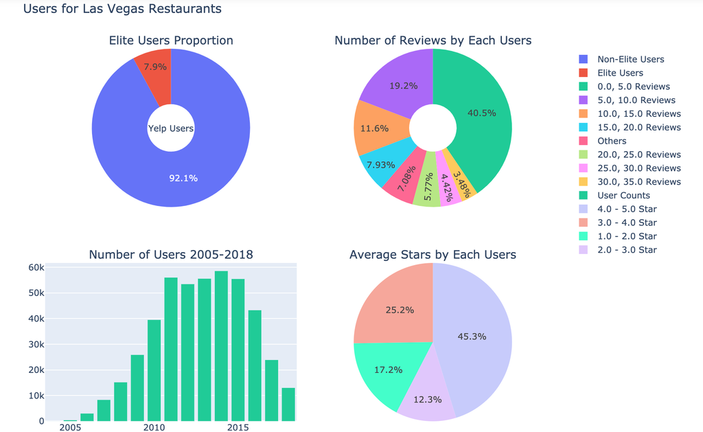

```python
display(Image('3-5.png'))
```

**Analysis 1.** Figure Elite users Proportion

**Analysis 2.** Number of Reviews by Each User

This is the number of reviews given by each users in an average user lifetime at Yelp till 2018. We have binned the users in different ranges to get the rough idea as there is maximum of 13708 reviews written by a user and this can become one of possible outlier while in-depth analysis. So binning is a great method to get rid of these outliers to get actual analysis.  
Almost 40.5% of the users review between 0-5 , which shows mostly people use the app to get to know a place before they can visit.

**Analysis 3.** Number of Users between 2005-2018

**Analysis 4.** Average Stars by Each User

This graph shows us the average stars given by a user in his entire reviews of Yelp Lifecycle. Suppose your are a Yelp User who has just given 5 reviews and all of them are 4 stars. So your Average review till date is 4 stars. We have binned stars in ranges as this is a continuous measure and plotting individual values can lead to infinity. We can see that people are pretty generous for restaurants at Vegas. I mean 45.3 % of them got 4-5 stars. So there can be two reasons for this

- Either people are drunk and gave the reviews
- Or Restaurants are really good at Vegas which is why it is one of busiest Nite city of United States.

**After preliminary analysis based on one dataset and simple dimension, we decide to merge two dataset and with more dimensions to get more insights.**

## 3.2 Merge Two Datasets

### 3.2.1 Business Type with Checkin Time

```python
# 'Catefories' is a multi-value column.
# We choose top 3 category type, and top 5 cuisine type.
# Create eight dummy variables for each businesses.
isNightLife = business.categories.str.contains('Nightlife')
isFastFood = business.categories.str.contains('Fast Food')
isCoffeeTea = business.categories.str.contains('Coffee & Tea')
isAmerican = business.categories.str.contains('American')
isMexican = business.categories.str.contains('Mexican')
isChinese = business.categories.str.contains('Chinese')
isItalian = business.categories.str.contains('Italian')
isJapanese = business.categories.str.contains('Japanese')
businessCat = pd.concat((business.iloc[:,:8], isNightLife, isFastFood, isCoffeeTea, isAmerican, isMexican, isChinese, isItalian, isJapanese), axis=1)
businessCat.columns = ['business_id', 'name', 'city', 'latitude', 'longtitude', 'stars', 'review_count', 'categories', 'isNightLife', 'isFastFood', 'isCoffeeTea', 'isAmerican', 'isMexican', 'isChinese', 'isItalian', 'isJapanese']
businessCat.head()
```

|  | business_id | name | city | latitude | longtitude | stars | review_count | categories | isNightLife | isFastFood | isCoffeeTea | isAmerican | isMexican | isChinese | isItalian | isJapanese |
| --- | --- | --- | --- | --- | --- | --- | --- | --- | --- | --- | --- | --- | --- | --- | --- | --- |
| 0 | PZ-LZzSlhSe9utkQYU8pFg | Carluccio's Tivoli Gardens | Las Vegas | 36.100016 | -115.128528 | 4.0 | 40 | Restaurants, Italian | False | False | False | False | False | False | True | False |
| 1 | tstimHoMcYbkSC4eBA1wEg | Maria's Mexican Restaurant & Bakery | Las Vegas | 36.195615 | -115.040529 | 4.5 | 184 | Mexican, Restaurants, Patisserie/Cake Shop, Fo... | True | False | False | False | True | False | False | False |
| 2 | NBn4hgfGtNz91k3VsDZlmw | Three Square | Las Vegas | 36.236053 | -115.096454 | 5.0 | 44 | Local Services, Food Banks, Community Service/... | False | False | False | False | False | False | False | False |
| 3 | kANF0dbeoW34s2vwh6Umfw | Dairy Queen | Las Vegas | 36.125031 | -115.225620 | 2.0 | 33 | Fast Food, Food, Restaurants, Ice Cream & Froz... | False | True | False | False | False | False | False | False |
| 4 | YK5eFV8uS1bCmp8GeiQ-Qg | All Star Donuts & Kolaches | Las Vegas | 36.115813 | -115.095457 | 4.0 | 6 | Food, Donuts | False | False | False | False | False | False | False | False |

```python
# Get business id Series for each type, save all Series to a dictionary 'typeDict'.
NightLifeId = businessCat[businessCat['isNightLife'] == True]['business_id']
FastFoodId = businessCat[businessCat['isFastFood'] == True]['business_id']
CoffeeTeaId = businessCat[businessCat['isCoffeeTea']== True]['business_id']
AmericanId = businessCat[businessCat['isAmerican']== True]['business_id']
MexicanId = businessCat[businessCat['isMexican']== True]['business_id']
ChineseId = businessCat[businessCat['isChinese']== True]['business_id']
ItalianId = businessCat[businessCat['isItalian']== True]['business_id']
JapaneseId = businessCat[businessCat['isJapanese']== True]['business_id']
typeDict = {'NightLifeId':NightLifeId, 'FastFoodId':FastFoodId, 'CoffeeTeaId':CoffeeTeaId, 'AmericanId':AmericanId, 'MexicanId':MexicanId, 'ChineseId':ChineseId, 'ItalianId':ItalianId, 'JapaneseId':JapaneseId}
```

```python
# Create a type name list.
typeList = ['isNightLife', 'isFastFood', 'isCoffeeTea', 'isAmerican', 'isMexican', 'isChinese', 'isItalian', 'isJapanese']

# Walk through each type, create dummny variables for business id in Checkin dataframe.
for istype in typeList:
    listName = istype[2:]+'Id'
    checkin[istype] = [business_id in list(typeDict[listName]) for business_id in list(checkin['business_id'])]
```

```python
checkin.head()
```

|  | business_id | date | isNightLife | isFastFood | isCoffeeTea | isAmerican | isMexican | isChinese | isItalian | isJapanese |
| --- | --- | --- | --- | --- | --- | --- | --- | --- | --- | --- |
| 0 | --9e1ONYQuAa-CB_Rrw7Tw | 2010-02-08 05:56:47, 2010-02-15 04:47:42, 2010... | False | False | False | False | False | False | False | False |
| 1 | --q7kSBRb0vWC8lSkXFByA | 2010-09-26 23:08:32, 2010-10-03 09:06:15, 2010... | True | False | False | False | False | False | False | False |
| 2 | -0BxAGlIk5DJAGVkpqBXxg | 2010-08-20 19:44:47, 2010-08-26 23:54:03, 2010... | False | False | True | False | False | False | False | False |
| 3 | -0RkJ_uIduNLWQrphbADRw | 2018-08-30 16:32:18, 2018-09-01 19:39:03, 2018... | False | False | True | False | False | False | False | False |
| 4 | -1m9o3vGRA8IBPNvNqKLmA | 2017-10-25 00:48:29, 2017-10-26 02:31:11, 2017... | True | False | False | True | False | False | False | False |

```python
# 'date' column in checkin dataframe is multi-valued.
# Expand the column and melt from wide to long.
# Merge single date to check-in dataframe.
# Save it as a new dataframe 'checkin_new'

checkin_new = pd.merge(checkin, checkin['date'].str.split(',',expand=True).melt().dropna(), left_index=True, right_on='variable')
```

```python
checkin_new.drop(['date', 'variable'], axis=1)
checkin_new.head()
```

|  | business_id | date | isNightLife | isFastFood | isCoffeeTea | isAmerican | isMexican | isChinese | isItalian | isJapanese | variable | value |
| --- | --- | --- | --- | --- | --- | --- | --- | --- | --- | --- | --- | --- |
| 0 | --9e1ONYQuAa-CB_Rrw7Tw | 2010-02-08 05:56:47, 2010-02-15 04:47:42, 2010... | False | False | False | False | False | False | False | False | 0 | 2010-02-08 05:56:47 |
| 1 | --9e1ONYQuAa-CB_Rrw7Tw | 2010-02-08 05:56:47, 2010-02-15 04:47:42, 2010... | False | False | False | False | False | False | False | False | 0 | 2010-09-26 23:08:32 |
| 2 | --9e1ONYQuAa-CB_Rrw7Tw | 2010-02-08 05:56:47, 2010-02-15 04:47:42, 2010... | False | False | False | False | False | False | False | False | 0 | 2010-08-20 19:44:47 |
| 3 | --9e1ONYQuAa-CB_Rrw7Tw | 2010-02-08 05:56:47, 2010-02-15 04:47:42, 2010... | False | False | False | False | False | False | False | False | 0 | 2018-08-30 16:32:18 |
| 4 | --9e1ONYQuAa-CB_Rrw7Tw | 2010-02-08 05:56:47, 2010-02-15 04:47:42, 2010... | False | False | False | False | False | False | False | False | 0 | 2017-10-25 00:48:29 |

```python
# Get 'hour' value from each check in value.
# Save it in the 'checkin_new' dataframe
dateAndTime = checkin_new['value'].str.strip().str.split(' ',expand=True)
checkin_new['Date'] = dateAndTime[0]
checkin_new['Time'] = dateAndTime[1]
checkin_new['Hour'] = checkin_new['Time'].str.slice(stop=2)
```

```python
# Save checkin hour list for each type in a 2D list 'hourList'.
hourList = []
for istype in typeList:
    hourList.append(checkin_new[checkin_new[istype]==True].groupby('Hour')['Date'].count())
```

```python
# Plot the checkin hour for each type
legendList = ['NightLife', 'FastFood', 'CoffeeTea', 'American', 'Mexican', 'Chinese', 'Italian', 'Japanese']

fig = go.Figure()
for i in range(len(hourList)):
    fig.add_trace(go.Scatter(x=list(range(0,24)), y=hourList[i], name=legendList[i],
                             line=dict(width=2)))

fig.update_layout(legend=dict(y=0.5, traceorder='reversed', font_size=16))
fig.update_layout(title='Check-in Time Distribution of Top Las Vegas Restaurant Types',
                   xaxis_title='Hour',
                   yaxis_title='check-in count')
fig.show()
```

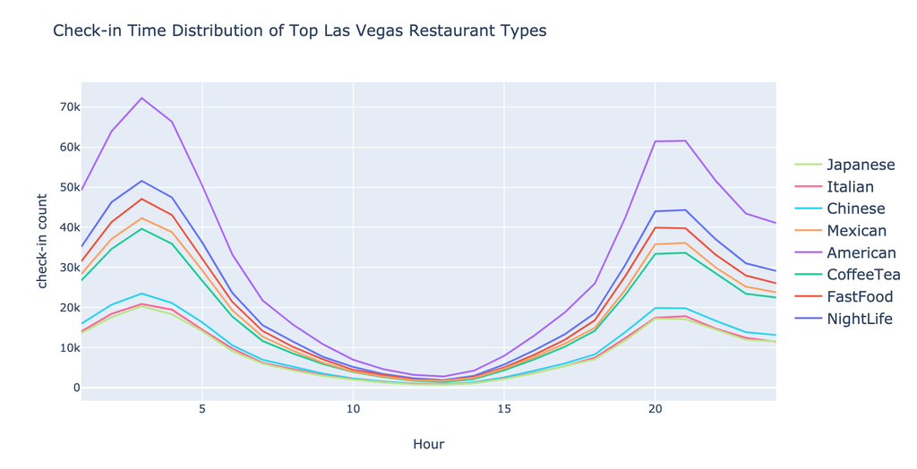

```python
display(Image('6.png'))
```

**Analysis:** To our surprise, all types of restaurant, even Japanese food and coffee and tea share the same pattern as the total restaurants. When traveling to Las Vegas, you can always find what you want to eat when you hanging out at night. After stayting up late, take a break at noon, just as everyone does in Las Vegas.

### 3.2.2 Business Location with Built Date

```python
# We use first check-in date as built date for that business,
# since it's the first check-in record in Yelp for that business.

checkin['builtDate'] = checkin['date'].str.split(',',expand=True)[0]
checkin.head()
```

|  | business_id | date | isNightLife | isFastFood | isCoffeeTea | isAmerican | isMexican | isChinese | isItalian | isJapanese | builtDate |
| --- | --- | --- | --- | --- | --- | --- | --- | --- | --- | --- | --- |
| 0 | --9e1ONYQuAa-CB_Rrw7Tw | 2010-02-08 05:56:47, 2010-02-15 04:47:42, 2010... | False | False | False | False | False | False | False | False | 2010-02-08 05:56:47 |
| 1 | --q7kSBRb0vWC8lSkXFByA | 2010-09-26 23:08:32, 2010-10-03 09:06:15, 2010... | True | False | False | False | False | False | False | False | 2010-09-26 23:08:32 |
| 2 | -0BxAGlIk5DJAGVkpqBXxg | 2010-08-20 19:44:47, 2010-08-26 23:54:03, 2010... | False | False | True | False | False | False | False | False | 2010-08-20 19:44:47 |
| 3 | -0RkJ_uIduNLWQrphbADRw | 2018-08-30 16:32:18, 2018-09-01 19:39:03, 2018... | False | False | True | False | False | False | False | False | 2018-08-30 16:32:18 |
| 4 | -1m9o3vGRA8IBPNvNqKLmA | 2017-10-25 00:48:29, 2017-10-26 02:31:11, 2017... | True | False | False | True | False | False | False | False | 2017-10-25 00:48:29 |

```python
# Merge built date with business dataframe.
builtDate = checkin.loc[:,['business_id','builtDate']]
businessWithBuiltDate = businessCat.merge(builtDate, left_on = 'business_id', right_on = 'business_id')
```

```python
# Create a new column 'builtYear' which derived from 'builtDate'
businessWithBuiltDate['builtYear'] = businessWithBuiltDate['builtDate'].str[:4]
businessWithBuiltDate.head()
```

|  | business_id | name | city | latitude | longtitude | stars | review_count | categories | isNightLife | isFastFood | isCoffeeTea | isAmerican | isMexican | isChinese | isItalian | isJapanese | builtDate | builtYear |
| --- | --- | --- | --- | --- | --- | --- | --- | --- | --- | --- | --- | --- | --- | --- | --- | --- | --- | --- |
| 0 | PZ-LZzSlhSe9utkQYU8pFg | Carluccio's Tivoli Gardens | Las Vegas | 36.100016 | -115.128528 | 4.0 | 40 | Restaurants, Italian | False | False | False | False | False | False | True | False | 2010-03-05 03:54:37 | 2010 |
| 1 | tstimHoMcYbkSC4eBA1wEg | Maria's Mexican Restaurant & Bakery | Las Vegas | 36.195615 | -115.040529 | 4.5 | 184 | Mexican, Restaurants, Patisserie/Cake Shop, Fo... | True | False | False | False | True | False | False | False | 2010-06-26 20:40:58 | 2010 |
| 2 | NBn4hgfGtNz91k3VsDZlmw | Three Square | Las Vegas | 36.236053 | -115.096454 | 5.0 | 44 | Local Services, Food Banks, Community Service/... | False | False | False | False | False | False | False | False | 2010-02-17 20:59:43 | 2010 |
| 3 | kANF0dbeoW34s2vwh6Umfw | Dairy Queen | Las Vegas | 36.125031 | -115.225620 | 2.0 | 33 | Fast Food, Food, Restaurants, Ice Cream & Froz... | False | True | False | False | False | False | False | False | 2010-07-05 00:23:21 | 2010 |
| 4 | YK5eFV8uS1bCmp8GeiQ-Qg | All Star Donuts & Kolaches | Las Vegas | 36.115813 | -115.095457 | 4.0 | 6 | Food, Donuts | False | False | False | False | False | False | False | False | 2011-11-14 23:04:02 | 2011 |

```python
# Mapbox token
mapbox_access_token = 'pk.eyJ1IjoicnVpbWFheCIsImEiOiJjazJucDFrM3YwMnZyM2ltd3p0c2dpM2N6In0.52B-BmR2dG3Bh8Ui_OfYUQ'

# Prepare data for plotting
yearList = ['2011','2012','2013','2014','2015','2016','2017','2018']
yearListCopy = [2011,2012,2013,2014,2015,2016,2017,2018]
businessWithBuiltDate['builtYearCopy'] = businessWithBuiltDate['builtYear'].astype(float)

data = [go.Scattermapbox(
               lat = [36.1],
               lon = [-115.2],
               mode = 'markers',
               marker = dict(size = 3.5, color = 'red', opacity = 0.5)
            )
        ]

# Plot each year's businesses map.
frames = [dict(data = [dict(type = 'scattermapbox',
                        lat = businessWithBuiltDate[businessWithBuiltDate['builtYearCopy'] <= year]['latitude'],
                        lon = businessWithBuiltDate[businessWithBuiltDate['builtYearCopy'] <= year]['longtitude'])],
               traces = [0],
               name = year
              )for year in yearListCopy]

# Set layout for the plot.
layout = go.Layout(width = 800,
    autosize = True,
    hovermode ='closest',
    mapbox = dict(accesstoken = mapbox_access_token,
                bearing = 0,
                center = dict(lat = 36.1,
                            lon = -115.2),
                pitch = 0,
                zoom = 9,
                style = 'light'
                )
            )

# Add sliders.
sliders = [dict(steps = [dict(method = 'animate',
                             label = year,
                           args = [[year],
                                  dict(mode = 'immediate',
                                  frame = dict( duration = 10, redraw = True ),
                                       transition = dict( duration = 0.5)
                                          )
                                    ],
                             ) for year in yearList],
                transition = dict(duration = 0 ),
                x = 0,
                y = 0,
                currentvalue = dict(visible = False),
                len = 1.0)
           ]

# Add button to play the slider automatically.
layout.update(updatemenus = [dict(type = 'buttons', showactive = False,
                                y = 0,
                                x = 1.05,
                                xanchor = 'right',
                                yanchor = 'top',
                                pad = dict(t = 0, r = 10),
                                buttons = [dict(label = 'Play',
                                              method = 'animate',
                                              args = [None,
                                                    dict(frame = dict(duration = 100,
                                                                    redraw = True),
                                                         transition = dict(duration = 0),
                                                         fromcurrent = True,
                                                         mode = 'immediate'
                                                        )
                                                   ]
                                             )
                                        ]
                               )
                          ],
              title ='Las Vegas Restaurant 2011-2018',
              sliders = sliders);

fig = go.Figure(data = data, layout = layout, frames = frames)
fig.show()
```

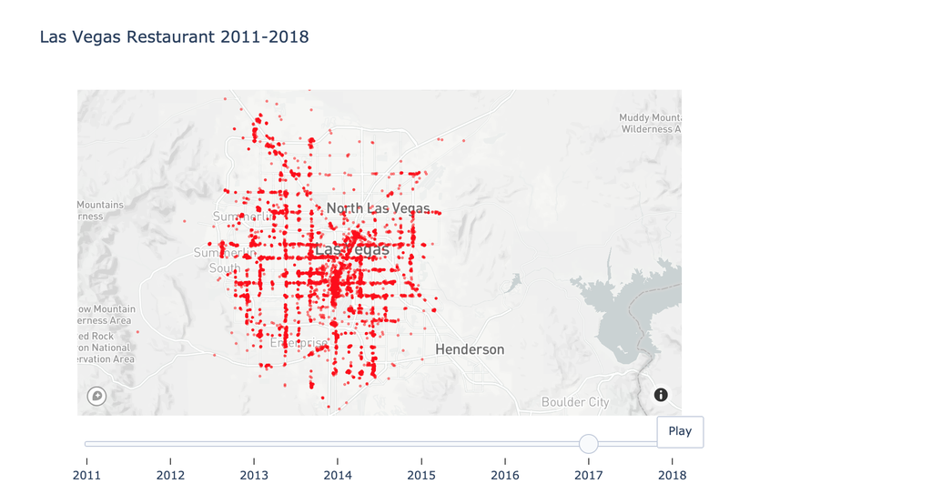

```python
display(Image('7.png'))
```

**Analysis:** From the map above, we can see the number of restaurants is growing rapidly all around Las Vegas. The popular streets are getting much more traction of users over time. From the center to surroundings, the density of restaurants is decreasing.

### 3.2.3 Business with Check-in Times

```python
# Create a new column 'year' which derived from 'Date' for dataframe 'checkin_new'
checkin_new['year'] = checkin_new['Date'].str[:4]
```

```python
# Merge two dataframes: business and 'checkin_new', save it to 'checkin_location'
checkin_location = businessCat.merge(checkin_new[['business_id', 'year']], left_on = 'business_id', right_on = 'business_id')
checkin_location.head()
```

|  | business_id | name | city | latitude | longtitude | stars | review_count | categories | isNightLife | isFastFood | isCoffeeTea | isAmerican | isMexican | isChinese | isItalian | isJapanese | year |
| --- | --- | --- | --- | --- | --- | --- | --- | --- | --- | --- | --- | --- | --- | --- | --- | --- | --- |
| 0 | PZ-LZzSlhSe9utkQYU8pFg | Carluccio's Tivoli Gardens | Las Vegas | 36.100016 | -115.128528 | 4.0 | 40 | Restaurants, Italian | False | False | False | False | False | False | True | False | 2018 |
| 1 | PZ-LZzSlhSe9utkQYU8pFg | Carluccio's Tivoli Gardens | Las Vegas | 36.100016 | -115.128528 | 4.0 | 40 | Restaurants, Italian | False | False | False | False | False | False | True | False | 2013 |
| 2 | PZ-LZzSlhSe9utkQYU8pFg | Carluccio's Tivoli Gardens | Las Vegas | 36.100016 | -115.128528 | 4.0 | 40 | Restaurants, Italian | False | False | False | False | False | False | True | False | 2015 |
| 3 | PZ-LZzSlhSe9utkQYU8pFg | Carluccio's Tivoli Gardens | Las Vegas | 36.100016 | -115.128528 | 4.0 | 40 | Restaurants, Italian | False | False | False | False | False | False | True | False | 2015 |
| 4 | PZ-LZzSlhSe9utkQYU8pFg | Carluccio's Tivoli Gardens | Las Vegas | 36.100016 | -115.128528 | 4.0 | 40 | Restaurants, Italian | False | False | False | False | False | False | True | False | 2015 |

```python
# Group 'checkin_location' dataframe by [business_id','name','year'],
# to get number of check-ins for each business in each year.
restaurant_checkin = checkin_location.groupby(['business_id','name','year']).count()['city']
restaurant_checkin = restaurant_checkin.reset_index()
restaurant_checkin.columns = ['business_id', 'name', 'check-in year', 'check-in times']

# Group by 'year'.
yearGroup = restaurant_checkin.groupby('check-in year')
```

```python
# Define a function to find out top 10 restaurants for a given year.
def MostVistRestaurant(year):
    year_df = yearGroup.get_group(year).sort_values(by='check-in times',ascending=False)
    year_top10 = year_df[:10].merge(businessWithBuiltDate, left_on = 'business_id', right_on = 'business_id')
    year_top10 = year_top10[['business_id','name_x','check-in times','latitude','longtitude','stars','categories']]
    simple_top10 = year_top10[['name_x','check-in times']]
    simple_top10.columns=[str(year)+'Top10', str(year)+'times']
    return simple_top10

# Merge Top 10 restaurants for each year from 2011 to 2018.
all_top10 = MostVistRestaurant('2011')
for year in yearList[1:]:
    all_top10 = pd.concat((all_top10, MostVistRestaurant(year)), axis=1)

# Show Top 10 restaurants in Las Vegas from 2011 to 2018.
all_top10['Rank']=list(range(1,11))
all_top10.set_index('Rank')
```

| Rank | 2011Top10 | 2011times | 2012Top10 | 2012times | 2013Top10 | 2013times | 2014Top10 | 2014times | 2015Top10 | 2015times | 2016Top10 | 2016times | 2017Top10 | 2017times | 2018Top10 | 2018times |
| --- | --- | --- | --- | --- | --- | --- | --- | --- | --- | --- | --- | --- | --- | --- | --- | --- |
| 1 | Smashburger | 1536 | In-N-Out Burger | 825 | Sin City Thai Restaurant | 728 | Rooster Boy Cafe | 650 | Ichi Ramen House | 624 | La Tapatia Market | 537 | Delmonico Steakhouse | 537 | Rooster Boy Cafe | 451 |
| 2 | The Neapolitan | 1530 | The Rice Shop | 824 | La Costa Del Sol | 711 | The Coffee Bean & Tea Leaf | 645 | Red Ginseng Narita Sushi & BBQ | 617 | Delmonico Steakhouse | 534 | Double Play Sports Bar | 532 | The Coffee Bean & Tea Leaf | 446 |
| 3 | Woo Chun Korean BBQ | 1526 | Smashburger | 823 | 8 Noodle Bar | 711 | Bavette's Steakhouse & Bar | 642 | AL's Donuts | 616 | The Perfect Scoop & Boba Tea | 534 | The Coffee Bean & Tea Leaf | 513 | Bavette's Steakhouse & Bar | 445 |
| 4 | Starbucks | 1524 | Merkato Ethiopian Cafe | 820 | 99 Ranch Market | 709 | The Neapolitan | 639 | Smashburger | 615 | Red Ginseng Narita Sushi & BBQ | 534 | AL's Donuts | 504 | La Tapatia Market | 440 |
| 5 | Ichi Ramen House | 1520 | K Jun Chicken | 819 | Starbucks | 707 | In-N-Out Burger | 637 | La Tapatia Market | 615 | Rooster Boy Cafe | 533 | Red Ginseng Narita Sushi & BBQ | 500 | Michael Mina | 440 |
| 6 | Fresh Buffet | 1520 | Taiga Modern Japanese & Thai Restaurant | 817 | The Butcher Block | 706 | Argana | 635 | The Perfect Scoop & Boba Tea | 614 | Bavette's Steakhouse & Bar | 531 | Michael Mina | 498 | AL's Donuts | 439 |
| 7 | The Butcher Block | 1516 | Toddy Shop | 816 | Michael Mina | 705 | Merkato Ethiopian Cafe | 634 | Starbucks | 614 | Sin City Thai Restaurant | 529 | La Tapatia Market | 498 | Vegas Uncork'd: The Grand Tasting | 434 |
| 8 | The Perfect Scoop & Boba Tea | 1516 | Medley Buffet | 814 | Dolphin Bar | 705 | Vegas Uncork'd: The Grand Tasting | 634 | Michael Mina | 613 | The Butcher Block | 529 | Vegas Uncork'd: The Grand Tasting | 497 | Red Ginseng Narita Sushi & BBQ | 432 |
| 9 | Sin City Thai Restaurant | 1514 | Pho Kinh Do | 813 | Panda Express | 705 | Woo Chun Korean BBQ | 633 | Double Play Sports Bar | 612 | Starbucks | 529 | Bavette's Steakhouse & Bar | 495 | Double Play Sports Bar | 425 |
| 10 | Argana | 1513 | Flame Kabob | 813 | Vegas Uncork'd: The Grand Tasting | 704 | Fresh Buffet | 632 | The Butcher Block | 612 | The Coffee Bean & Tea Leaf | 529 | Rooster Boy Cafe | 492 | Sin City Thai Restaurant | 425 |

### 3.2.4 Business Type with Location

```python
# Mapbox token
mapbox_access_token = 'pk.eyJ1IjoicnVpbWFheCIsImEiOiJjazJucDFrM3YwMnZyM2ltd3p0c2dpM2N6In0.52B-BmR2dG3Bh8Ui_OfYUQ'

# Prepare data for all restaurants and NightLife restaurants.
restaurant_map_data = [go.Scattermapbox(
        lon = businessWithBuiltDate['longtitude'],
        lat = businessWithBuiltDate['latitude'],
        text = businessWithBuiltDate['name'],
        hoverinfo='text',
        mode = 'markers',
        marker = dict(
                    color = 'black',
                    symbol = 'circle',
                    size = 4,
                    opacity = .5
                ),
        name = 'general restaurant'
),
                       go.Scattermapbox(
        lon = businessWithBuiltDate[businessWithBuiltDate['isNightLife']==True]['longtitude'],
        lat = businessWithBuiltDate[businessWithBuiltDate['isNightLife']==True]['latitude'],
        text = businessWithBuiltDate[businessWithBuiltDate['isNightLife']==True]['name'] + '<br>' + 'NightLife',
        hoverinfo='text',
        mode = 'markers',
        marker = dict(
                    color = 'red',
                    symbol = 'circle',
                    size = 4,
                    opacity = .5
                ),
        name = 'NightLife')]

# Add plot title and mapbox token
restaurant_map_layout = go.Layout(
        title = 'Yelp Reastaurants In Las Vegas',
        mapbox=go.layout.Mapbox(
            accesstoken=mapbox_access_token,
            #zoom=0
        )
    )

restaurant_map = go.Figure(data=restaurant_map_data, layout=restaurant_map_layout)
restaurant_map.update_layout(mapbox_center_lat=36.1, mapbox_center_lon=-115.2, mapbox_zoom = 9)
restaurant_map.show()
```

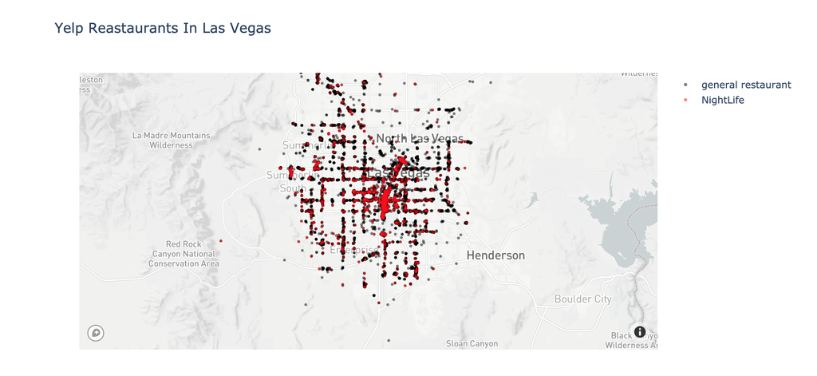

```python
display(Image('8.png'))
```

**Analysis:** Las Vegas has restaurant all city around. However, for NightLife, they are more concentrate on the main street.

### 3.2.4 Score with Business Location

```python
# Create heatmap using business latitude, longitude and stars.
star_fig = go.Figure(
    go.Densitymapbox(lat=businessWithBuiltDate['latitude'],
                     lon=businessWithBuiltDate['longtitude'],
                     z=businessWithBuiltDate['stars'], radius=4))
star_fig.update_layout(mapbox_style="stamen-terrain")
star_fig.update_layout(title='Restaurant Score HeatMap in las Vegas')
star_fig.update_layout(mapbox_center_lat=36.1, mapbox_center_lon=-115.2, mapbox_zoom = 10)

star_fig.show()
```

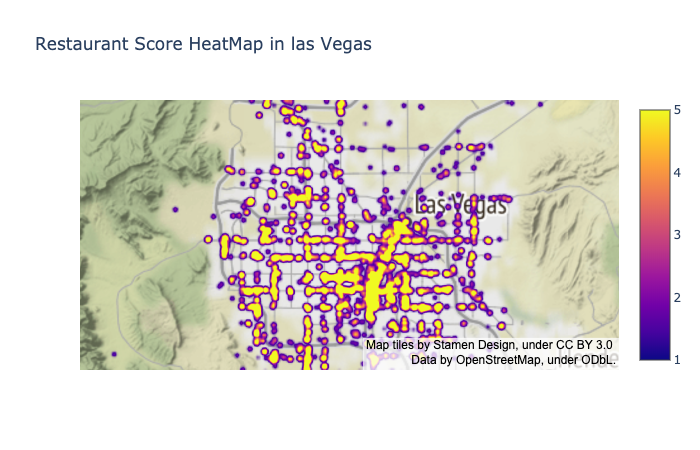

```python
display(Image('9.png'))
```

**Analysis:** Yellow dots represent the restaurants which have been rated more than 4 stars by the users. And purple dots depict restaurants with ratings <2. We can see that good restaurants are more concentrated on Las Vegas main Street. This Street also marks the most popular nightlife zone.

### 3.2.5 Score with Business Type

```python
# Filter out 'stars' column in Business dataset.
# Merge score distribution for different type of restaurants in a new dataframe 'allTypeStar'
allTypeStar = businessWithBuiltDate[businessWithBuiltDate['isNightLife']==True]['stars'].value_counts().sort_index()
for istype in typeList:
    newSeries = businessWithBuiltDate[businessWithBuiltDate[istype]==True]['stars'].value_counts().sort_index()
    allTypeStar = pd.concat((allTypeStar, newSeries),axis=1)

allTypeStar.columns = [['s1','s2','s3','s4','s5','s6','s7','s8','s9']]
allTypeStar = allTypeStar.drop(['s1'],axis=1)
allTypeStar.columns = typeList
allTypeStar = allTypeStar.fillna(0)
allTypeStar
```

|  | isNightLife | isFastFood | isCoffeeTea | isAmerican | isMexican | isChinese | isItalian | isJapanese |
| --- | --- | --- | --- | --- | --- | --- | --- | --- |
| 1.0 | 1 | 12 | 9 | 1 | 1 | 2 | 1 | 0.0 |
| 1.5 | 4 | 72 | 25 | 9 | 11 | 7 | 3 | 1.0 |
| 2.0 | 17 | 194 | 69 | 49 | 33 | 22 | 23 | 3.0 |
| 2.5 | 68 | 214 | 102 | 165 | 93 | 42 | 34 | 11.0 |
| 3.0 | 150 | 205 | 116 | 261 | 151 | 111 | 60 | 41.0 |
| 3.5 | 296 | 139 | 131 | 355 | 197 | 142 | 126 | 84.0 |
| 4.0 | 329 | 92 | 156 | 379 | 181 | 94 | 134 | 140.0 |
| 4.5 | 135 | 42 | 123 | 169 | 119 | 41 | 52 | 86.0 |
| 5.0 | 23 | 8 | 27 | 30 | 32 | 4 | 8 | 10.0 |

```python
# Data
r = [0,1,2,3,4,5,6,7]
df = allTypeStar.T
df.fillna(0)

# From count number of each score to percentage
totals = [s1+s2+s3+s4+s5+s6+s7+s8+s9 for s1,s2,s3,s4,s5,s6,s7,s8,s9 in zip(df[1.0], df[1.5], df[2.0], df[2.5], df[3.0], df[3.5], df[4.0], df[4.5], df[5])]
s1Bars = [i / j * 100 for i,j in zip(df[1.0], totals)]
s2Bars = [i / j * 100 for i,j in zip(df[1.5], totals)]
s3Bars = [i / j * 100 for i,j in zip(df[2.0], totals)]
s4Bars = [i / j * 100 for i,j in zip(df[2.5], totals)]
s5Bars = [i / j * 100 for i,j in zip(df[3.0], totals)]
s6Bars = [i / j * 100 for i,j in zip(df[3.5], totals)]
s7Bars = [i / j * 100 for i,j in zip(df[4.0], totals)]
s8Bars = [i / j * 100 for i,j in zip(df[4.5], totals)]
s9Bars = [i / j * 100 for i,j in zip(df[5.0], totals)]
```

```python
# Plot each score bar for each type.
names=typeList
fig = go.Figure(go.Bar(x=names, y=s1Bars, name='1.0'))
fig.add_trace(go.Bar(x=names, y=s2Bars, name='1.5'))
fig.add_trace(go.Bar(x=names, y=s3Bars, name='2.0'))
fig.add_trace(go.Bar(x=names, y=s4Bars, name='2.5'))
fig.add_trace(go.Bar(x=names, y=s5Bars, name='3.0'))
fig.add_trace(go.Bar(x=names, y=s6Bars, name='3.5'))
fig.add_trace(go.Bar(x=names, y=s7Bars, name='4.0'))
fig.add_trace(go.Bar(x=names, y=s8Bars, name='4.5'))
fig.add_trace(go.Bar(x=names, y=s9Bars, name='5.0'))

fig.update_layout(barmode='stack', xaxis={'categoryorder':'array', 'categoryarray':['d','a','c','b']})

fig.update_layout(title='Score Distribution of Top Las Vegas Restaurant Types',
                   xaxis_title='Type',
                   yaxis_title='Percentage')
fig.show()
```

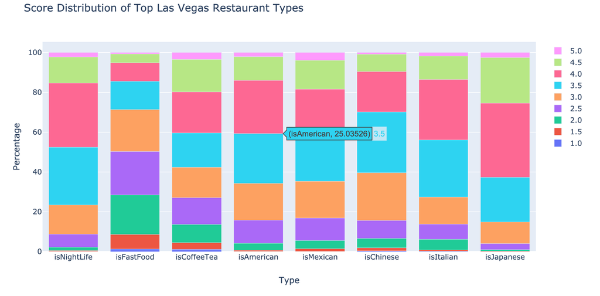

```python
display(Image('10.png'))
```

**Analysis:** From the graph above, we can see the score distribution for each popupar restaurant type. What interesting is that for NightLife and Japanese restaurant, apparently we have a higher proportion of >3 restaurants than other types. We conclude that Las Vegas has really good Nightlife and Japanese food. Compared to other types, Fast food and Chinese food are not as good.

## 3.3 Sentimental Analysis

```python
rev = pd.read_csv("review.csv")
ser = pd.read_csv("business.csv")

# Creating 2 empty lists to hold buiness Ids for Italian & Mexican restaurants respectively.
# Since the dataset is too large, we decide to go with only part of it.
# Mexican is a very popular type of restaurants in Las Vegas.
# Meanwhile, we choose Italian as a comparison city.

italian = []
mexican = []

# fetching the business Ids for restaurants serving Italian cuisine & Mexican cuisine.

for i in range(len(ser)):
    if 'Italian' in ser['categories'][i]:
        italian.append(ser['business_id'][i])

    if 'Mexican' in ser['categories'][i]:
        mexican.append(ser['business_id'][i])
```

```python
# Creating 2 empty lists to hold reviews for Italian & Mexican restaurants respectively.

ls_italian = []
ls_mexican = []

# for business Ids fetched above, fetching their respective reviews

for i in range(len(rev)):

    if rev['business_id'][i] in italian:
        if type(rev['text'][i])==str:
            ls_italian.append(rev['text'][i])
    else:
        continue

    if rev['business_id'][i] in mexican:
        if type(rev['text'][i])==str:
            ls_mexican.append(rev['text'][i])
    else:
        continue
```

```python
# Total number of reviews for Italian & Mexican restaurants

print("No. of Italian restaurants whose reviews are available : ", len(ls_italian))
print("No. of Mexican restaurants whose reviews are available : ", len(ls_mexican))
```

```
No. of Italian restaurants whose reviews are available :  111243
No. of Mexican restaurants whose reviews are available :  1766
```

```python
# Tokenizing reviews of Italian restaurants for NLP

tkn_italian = []

for i in range(len(ls_italian)):

    # processing each review
    text_it = ls_italian[i]

    # converting each review sentence to tokens
    tokens_it = [w for w in word_tokenize(text_it.lower()) if w.isalpha()]

    # removing the stopwords from the tokens_it
    no_stops_it = [t for t in tokens_it if t not in stopwords.words('english')]

    # Stemming each word in no_stops_it
    ps_it = PorterStemmer()
    stem_words_it = [ps_it.stem(word) for word in no_stops_it]

    # Lemmatizing each word in stemmed words
    word_lemmatizer_it = WordNetLemmatizer()
    lemmatized_it = [word_lemmatizer_it.lemmatize(t) for t in stem_words_it]

    # creating a list of all the words in the review
    tkn_italian.append(lemmatized_it)
```

```python
# Tokenizing reviews of Mexican restaurants for NLP

tkn_mexican = []

for i in range(len(ls_mexican)):

    # processing each review
    text_mx = ls_mexican[i]

    # converting each review sentence to tokens
    tokens_mx = [w for w in word_tokenize(text_mx.lower()) if w.isalpha()]

    # removing the stopwords from the tokens_it
    no_stops_mx = [t for t in tokens_mx if t not in stopwords.words('english')]

    # Stemming each word in no_stops_it
    ps_mx = PorterStemmer()
    stem_words_mx = [ps_mx.stem(word) for word in no_stops_mx]

    # Lemmatizing each word in stemmed words
    word_lemmatizer_mx = WordNetLemmatizer()
    lemmatized_mx = [word_lemmatizer_mx.lemmatize(t) for t in stem_words_mx]

    # creating a list of all the words in the review
    tkn_mexican.append(lemmatized_mx)
```

```python
# converting the sublists in tkn_italian and tkn_mexican as flat lists

flat_list_italian = [item for sublist in tkn_italian for item in sublist]
flat_list_mexican = [item for sublist in tkn_mexican for item in sublist]
```

```python
# calculating the frequency of words in italian reviews and mexican reviews

from nltk.text import Text

fd_italian = FreqDist(Text(flat_list_italian))
fd_mexican = FreqDist(Text(flat_list_mexican))
```

```python
# Most frequent 10 words in Italian reviews
fd_italian.most_common(10)
```

```
[('food', 82836),
 ('good', 71834),
 ('place', 65227),
 ('order', 62536),
 ('pizza', 60939),
 ('great', 57457),
 ('servic', 52665),
 ('time', 46226),
 ('like', 45938),
 ('restaur', 40329)]
```

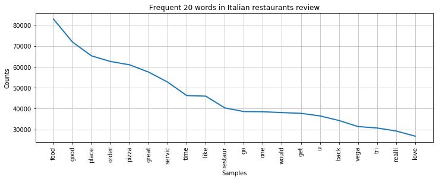

```python
# Visualize frequency of most common words in italian reviews

plt.figure(figsize=(12,4))
fd_italian.plot(20, title = "Frequent 20 words in Italian restaurants review")
```

**Analysis:** The above graph plots the most frequent 20 words being used in Italian restaurants review in Las Vegas. It may be seen that words like 'food','good','place','order', 'pizza' have been used more frequently than rest of the words in the reviews

```python
# Most frequent 10 words in Mexican reviews

fd_mexican.most_common(10)
```

```
[('food', 1353),
 ('good', 1320),
 ('order', 980),
 ('like', 940),
 ('servic', 906),
 ('place', 905),
 ('restaur', 872),
 ('pizza', 848),
 ('one', 832),
 ('great', 831)]
```

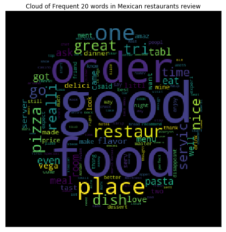

```python
# Visualize word cloud of most common words in Mexican reviews

x, y = np.ogrid[:300, :300]

mask = (x - 150) ** 2 + (y - 150) ** 2 > 130 ** 2
mask = 255 * mask.astype(int)

wc = WordCloud(background_color='black', mask = mask).generate(' '.join(flat_list_mexican))
plt.figure(figsize=(8,8))
plt.xticks([])
plt.yticks([])
plt.imshow(wc)
plt.title("Cloud of Frequent 20 words in Mexican restaurants review");
```

**Analysis:** This visualization represents the word cloud of most frequent words used in reviews of Mexican restaurants. It may be seen words like 'good', 'food', 'order' have been used more frequently than others words in Mexican reviews.

```python
# from the above bag of words for various cuisine types, getting the positive
# and negative words used by the reviewers to express their sentiment

positive = ['good', 'great', 'nice', 'best', 'love', 'happy', 'recommend', 'delight', 'delicious', 'yummy', 'super', 'excellent', 'awesome', 'enjoy']
negative = ['bad', 'worse', 'worst', 'hate', 'unhappy', 'problem', 'rude', 'horrible', 'disappoint', 'upset']
```

```python
# Checking out the frequency of positive sentiments and negative sentiments for Italian
# restaurants in Las Vegas

p1 = 0
n1 = 0

for i in range(len(flat_list_italian)):
    if flat_list_italian[i] in positive:
        p1 = p1+1

    elif flat_list_italian[i] in negative:
        n1 = n1+1

p1 = (p1*100)/len(flat_list_italian)
n1 = (n1*100)/len(flat_list_italian)
```

```python
# Checking out the frequency of positive sentiments and negative sentiments for
# Mexican restaurants in Las Vegas

p2 = 0
n2 = 0

for i in range(len(flat_list_mexican)):
    if flat_list_mexican[i] in positive:
        p2 = p2+1

    elif flat_list_mexican[i] in negative:
        n2 = n2+1

p2 = (p2*100)/len(flat_list_mexican)
n2 = (n2*100)/len(flat_list_mexican)
```

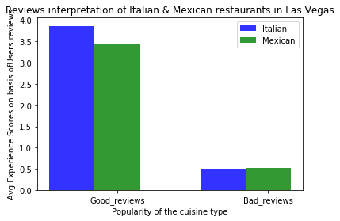

```python
# data to plot
n_groups = 2
it = (p1,n1)
mx = (p2,n2)

# create plot
fig, ax = plt.subplots()
index = np.arange(n_groups)
bar_width = 0.3
opacity = 0.8

rects1 = plt.bar(index, it, bar_width,alpha=opacity,color='b',label='Italian')

rects2 = plt.bar(index + bar_width, mx, bar_width,alpha=opacity,color='g',label='Mexican')

plt.xlabel('Popularity of the cuisine type')
plt.ylabel('Avg Experience Scores on basis ofUsers reviews')
plt.title('Reviews interpretation of Italian & Mexican restaurants in Las Vegas')
plt.xticks(index + bar_width, ('Good_reviews', 'Bad_reviews'))
plt.legend()

plt.show()
```

**Analysis:** From the bar graph, it may be seen that in city of Las Vegas, when we compare Italian and Mexican restaurants, good review of Italian restaurants are more than Mexican restaurants. Also, it may be seen that bad reviews for Italian restaurants are less than Mexican restaurants. This implies that in comparison to Mexican restaurants, Italian restaurants are more popular in Las Vegas.

# 4. Major Findings

- We find the most popular types of restaurants in Las Vegas. Top 10 types by category are Nightlife, Fast Food, Bars, Coffee & Tea, Sandwiches, Pizza, Burgers, Breakfast & Brunch, Specialty Food, Desserts. Top 10 types by region are American (Traditional), Mexican, American (New), Chinese, Italian, Japanese, Thai, Mediterranean, Hawaiian, Korean.
- Las Vegas never let people hungry, even in the midnight. The restaurant check-in peak is 2 am. All types of restaurant, even Japanese food and coffee and tea share the same pattern as the total restaurants.
- The total number of Yelp users increased from 2005 to 2014. However, after 2015 there starts the downfall of the Yelp as Google, Apple Siri and other competitors enter the market making it difficult for Yelp to attract their customer leaving a review.
- For Yelp users in Las Vegas, we find less than 10% are elite users for Yelp, 40% of them write less than 5 reviews. People are not so passionate to write reviews for Las Vegas.
- There is a high proportion of restaurants over 4 stars. One reason is that people in Las Vegas are generous to Las Vegas restaurants, another explanation is restaurants are really good here, which also makes sense to a tourist city as Las Vegas. Among all the types, NightLife and Japanese are exceptionally good in Las Vegas.
- A large volume of good restaurants and also Nightlife restaurant are on the center street. That's the best place to meet a restaurant you may like without doing any research.
- When talked about Italian food and Mexican food, 'good' is one the most frequent used word people use. Italian food enjoyed a higher percentage of good reviews over Mexican food.

### Why our results are meaningful?

- For Yelp, we detect a decrease in user base from 2015 and a lack of motivation to write reviews, which is an important signal for Yelp to put more effort into attracting new users and encouraging users interaction.
- For business owners, we provide insights in restaurants operation time, location and competitors performance, which could be used to positioning themselves in Las Vegas restaurant market.
- For residents and visitors, we give suggestions on popular restaurant types, top 10 restaurants over the years and geographical distibution of good restaurants, which can be helpful when looking for something to eat in Las Vegas.

# #END and Thank You : )